# Computer Vision project - COVID-19 Image Classification

### Data Description:

- You are provided with a training set and a test set of images of 3 classes.
- Each image has a filename that is its unique id.
- The dataset comprises 3 classes: COVID-19, Viral Pneumonia, and Normal.
- The goal of the project is to create a classifier capable of determining the class of the x-ray image.

### Dataset:

The project is inspired from a dataset from Kaggle. Note: For project purposes, the dataset is modified according to the learning requirements. You are provided with the following files:

- testimage.npy
- testLabels.csv
- trainimage.npy
- trainLabels.csv

The dataset(above 4 files)has to be downloaded from Olympus platform of Great Learning.

### Context:

- Can you differentiate an X-ray image of a normal person from an unhealthy one?
- The ability to do so effectively can mean better diagnosis.

### Objective:

- To implement the techniques learnt as a part of the course.

### Learning Outcomes:

- Pre-processing of image data.
- Visualization of images.
- Building CNN.
- Evaluate the Model.

```python
# Import necessary libraries.
import cv2
import math
import numpy as np
import os
import pandas as pd
import seaborn as sns
from glob import glob
from matplotlib import pyplot as plt
from sklearn.metrics import confusion_matrix

from tensorflow.keras.models import Sequential
from tensorflow.keras.layers import Dense, Dropout, Flatten, Conv2D, MaxPool2D, GlobalMaxPooling2D
from tensorflow.keras.layers import BatchNormalization
from tensorflow.keras.optimizers import RMSprop, Adam
from keras.utils.np_utils import to_categorical # convert to one-hot-encoding
from tensorflow.keras.preprocessing.image import ImageDataGenerator
```

```python
from google.colab import drive
drive.mount('/content/drive/')
```

```python
os.chdir('/content/drive')
```

```python
# Load the image file of dataset
train_images = np.load('My Drive/Colab Notebooks/data/trainimage.npy')
test_images = np.load('My Drive/Colab Notebooks/data/testimage.npy')
# Load the labels file of dataset
train_labels = pd.read_csv('My Drive/Colab Notebooks/data/trainLabels.csv')
test_labels = pd.read_csv('My Drive/Colab Notebooks/data/testLabels.csv')
```

```python
print(train_images.shape)
print(train_labels.shape)
print(test_images.shape)
print(test_labels.shape)
```

```
(251, 128, 128, 3)
(251, 1)
(66, 128, 128, 3)
(66, 1)
```

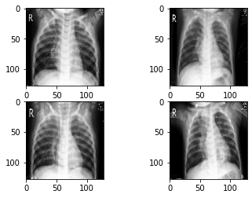

```python
# Look at some example images in training set
for i in range(4):
    plt.subplot(2, 2, i + 1)
    plt.imshow(train_images[i])
```

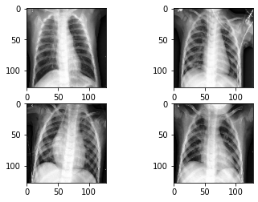

```python
# Look at some example images in test set
for i in range(4):
    plt.subplot(2, 2, i + 1)
    plt.imshow(test_images[i])
```

```python
train_labels.sample(5)
```

|  | Label |
| --- | --- |
| 85 | Covid |
| 110 | Covid |
| 44 | Viral Pneumonia |
| 55 | Viral Pneumonia |
| 5 | Viral Pneumonia |

```python
test_labels.sample(5)
```

|  | Label |
| --- | --- |
| 29 | Covid |
| 53 | Normal |
| 49 | Normal |
| 61 | Normal |
| 43 | Covid |

```python
train_labels['Label'].value_counts()
```

```
Covid              111
Viral Pneumonia     70
Normal              70
Name: Label, dtype: int64
```

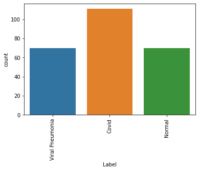

```python
sns.countplot(train_labels['Label'])
plt.xticks(rotation='vertical')
```

```python
test_labels['Label'].value_counts()
```

```
Covid              26
Viral Pneumonia    20
Normal             20
Name: Label, dtype: int64
```

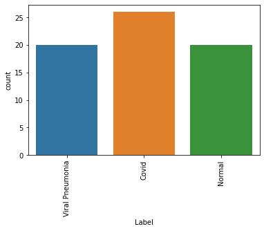

```python
sns.countplot(test_labels['Label'])
plt.xticks(rotation='vertical')
```

```python
Labels = ['Covid', 'Normal', 'Viral Pneumonia']
```

## Exploratory Data Analysis

### Plotting mean images

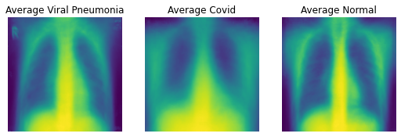

```python
def find_mean_img(full_mat):
    # calculate the average
    mean_img = np.mean(full_mat, axis = 0)
    # reshape it back to a matrix
    mean_img = mean_img.reshape((150,150))

    return mean_img

CATEGORIES= train_labels['Label'].unique()
d={ i:[] for i in CATEGORIES}

for i in train_labels.index:
  gray = cv2.cvtColor(train_images[i], cv2.COLOR_BGR2GRAY)
  gray = cv2.resize(gray,(150,150))
  d[train_labels['Label'][i]].append(gray)

l=[]
for i in d.keys():
  l.append(find_mean_img(d[i]))

plt.subplots(figsize=(12,12))
for i in range(len(l)):
    plt.subplot(3,4,i + 1,title='Average '+list(d.keys())[i])
    plt.imshow(l[i])
    plt.axis('off')
```

## Data Preprocessing: Image Preprocessing

**In order to remove the noise, we will have to blur the images (Gaussian Blurring)**

**In order to remove the background, we will use a threshold.**

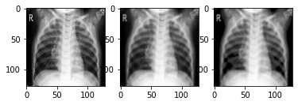

```
# CLEANED IMAGES
```

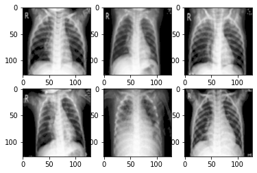

```python
new_train = []
sets = []; getEx = True
for i in train_images:
    blurr = cv2.GaussianBlur(i,(3,3),0)
    ret, thresh_image = cv2.threshold(blurr, 30, 90, cv2.THRESH_TOZERO)
    new_train.append(thresh_image)
    if getEx:
        plt.subplot(2,3,1);plt.imshow(i) # original image
        plt.subplot(2,3,2);plt.imshow(blurr) # blurred image
        plt.subplot(2,3,3);plt.imshow(thresh_image) # mask image
        plt.show()
        getEx = False
new_train = np.asarray(new_train) # make numpy array
print("# CLEANED IMAGES")
for i in range(6):
    plt.subplot(2,3,i+1)
    plt.imshow(new_train[i])
```

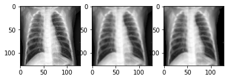

```
# CLEANED IMAGES
```

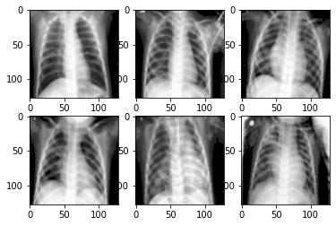

```python
new_test = []
sets = []; getEx = True
for i in test_images:
    blurr = cv2.GaussianBlur(i,(3,3),0)
    ret, thresh_image = cv2.threshold(blurr, 30, 90, cv2.THRESH_TOZERO)
    new_test.append(thresh_image)
    if getEx:
        plt.subplot(2,3,1);plt.imshow(i) # original image
        plt.subplot(2,3,2);plt.imshow(blurr) # blurred image
        plt.subplot(2,3,3);plt.imshow(thresh_image) # mask image
        plt.show()
        getEx = False
new_test = np.asarray(new_test) # make numpy array
print("# CLEANED IMAGES")
for i in range(6):
    plt.subplot(2,3,i+1)
    plt.imshow(new_test[i])
```

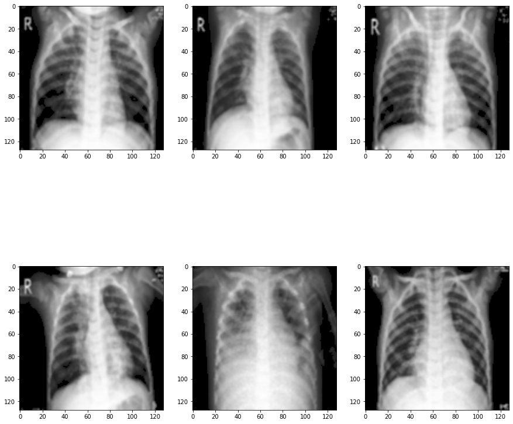

```python
fig = plt.figure(figsize=(15, 15))  # width, height in inches

for i in range(6):
    sub = fig.add_subplot(2, 3, i + 1)
    sub.imshow(new_train[i])
```

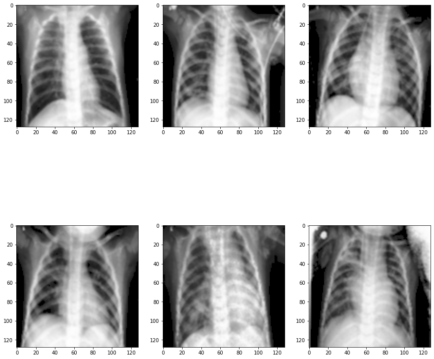

```python
fig = plt.figure(figsize=(15, 15))  # width, height in inches

for i in range(6):
    sub = fig.add_subplot(2, 3, i + 1)
    sub.imshow(new_test[i])
```

```python
# Normalize train image data.
new_train = new_train / 255
# Normalize test image data.
new_test = new_test / 255
```